# R Notebook

# EDA

## loading data set

## generate subset

I reviewed the data set in a csv viewer to get a feel for it. Noise level has weird rounding thing going on.

It would be interesting to see if rounding can be predicted or is useful.

## checking for duplicates

```r
#View(subset_cars[duplicated(subset_cars),])
print(sum(duplicated(subset_cars)))
```

```
[1] 66
```

```r
print(sum(duplicated(subset_cars["model"])))
```

```
[1] 1730
```

```r
print(sum(duplicated(subset_cars[c("urban_metric", "noise_level", "co2")])))
```

```
[1] 598
```

OK some duplicates. In theory it shouldn’t be impossible … but IDK if this was intended when gathering the data … A more in depth study of duplicates could be done using clustering techniques.

## are there missing values?

```r
sum(is.na(subset_cars))
```

```
[1] 0
```

## what can I plot?

```r
names(subset_cars)
```

```
 [1] "manufacturer"       "model"              "description"        "euro_standard"      "transmission_type"  "engine_capacity"    "fuel_type"
 [8] "urban_metric"       "extra_urban_metric" "combined_metric"    "noise_level"        "co2"                "co_emissions"       "nox_emissions"
```

```r
str(subset_cars)
```

```
'data.frame':   3000 obs. of  14 variables:
 $ manufacturer      : chr  "Vauxhall" "Mitsubishi" "Ford" "Mercedes-Benz" ...
 $ model             : chr  "Zafira, MY2004" "Carisma" "Focus, Model Year Pre 2010Â¼" "C-Class Saloon Model Year 2012" ...
 $ description       : chr  "1.8 16v Life 5 Door From VIN: W0L0TGF7542102926" "1.8 GDI EQUIPPE 4/5 DOOR" "1.6 Duratorq TDCi (90PS) 5 Door Saloon" "C 200 CDI with 16 inch rear wheels 195/60 Tyres ECO Start/Stop" ...
 $ euro_standard     : Factor w/ 3 levels "3","4","5": 2 1 3 3 2 3 3 3 2 3 ...
 $ transmission_type : Factor w/ 2 levels "Automatic","Manual": 2 2 2 1 2 1 2 2 2 1 ...
 $ engine_capacity   : int  1796 1834 1560 2143 1390 2993 1956 1598 2616 2967 ...
 $ fuel_type         : Factor w/ 2 levels "Diesel","Petrol": 2 2 1 1 2 1 1 2 2 1 ...
 $ urban_metric      : num  11 9.2 5.8 6.1 8.6 9 7.7 8.3 15.7 7 ...
 $ extra_urban_metric: num  6.5 5.7 3.8 4.3 5.6 5.7 4.7 5.1 9.1 5.2 ...
 $ combined_metric   : num  8.2 7 4.5 4.9 6.7 6.9 5.8 6.3 11.5 5.9 ...
 $ noise_level       : num  73 73 69 70 72 69 72 71 74 69 ...
 $ co2               : int  196 168 119 129 159 181 154 147 299 154 ...
 $ co_emissions      : num  627 168 453 68 335 375 162 446 220 261 ...
 $ nox_emissions     : num  8 101 132 157 56 150 162 12 29 149 ...
```

## univariate plots for factor types

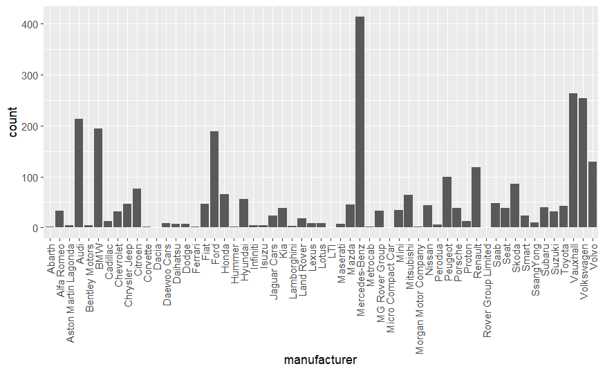

```r
# (for future me) for loop doesn't work and dont plot model
ggplot(subset_cars ,aes(manufacturer)) + geom_bar(stat ="count")+
  theme(axis.text.x=element_text(angle=90,hjust=1,vjust=0.5))
```

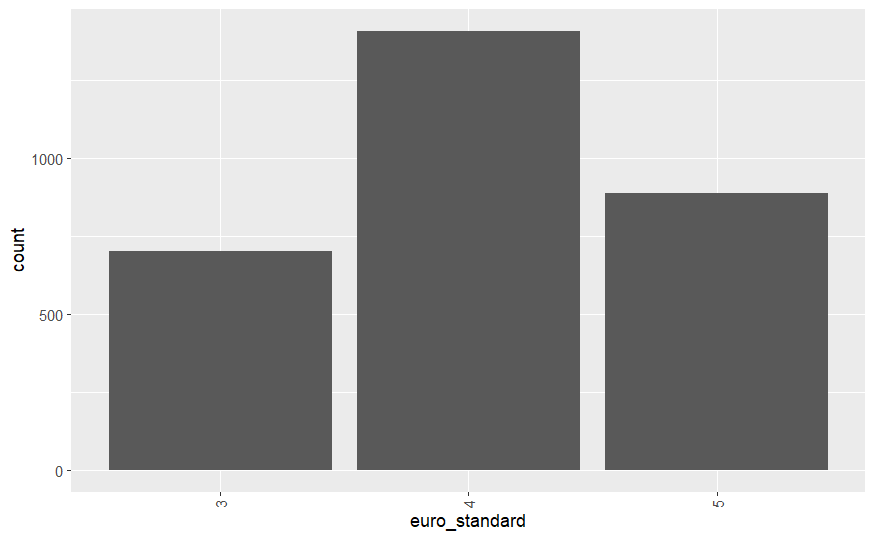

```r
ggplot(subset_cars ,aes(euro_standard)) + geom_bar(stat ="count")+
  theme(axis.text.x=element_text(angle=90,hjust=1,vjust=0.5))
```

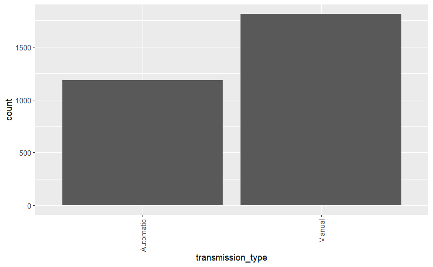

```r
ggplot(subset_cars ,aes(transmission_type)) + geom_bar(stat ="count")+
  theme(axis.text.x=element_text(angle=90,hjust=1,vjust=0.5))
```

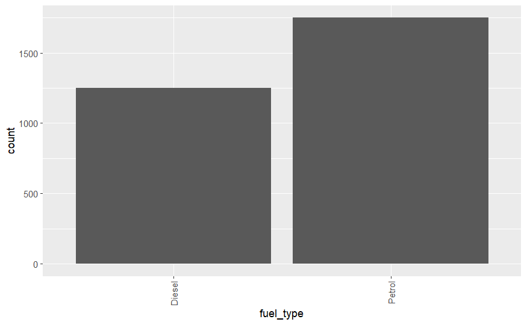

```r
ggplot(subset_cars ,aes(fuel_type)) + geom_bar(stat ="count")+
  theme(axis.text.x=element_text(angle=90,hjust=1,vjust=0.5))
```

Everything looks balanced minus the manufacturer. From our humble car knowledge we think that there are major differences between cars from different manufacturers (you shouldn’t compare a Lamborghini with a mini it just has other stats). This probably gives a problem with balancing (whatever we mean). We are not sure that the counts represents the amount of cars in Europe? Later we’ll look into it.

## plots for numerical types

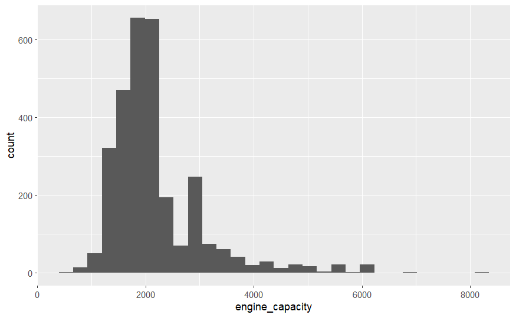

```r
ggplot(subset_cars,aes(engine_capacity))+ geom_histogram()
```

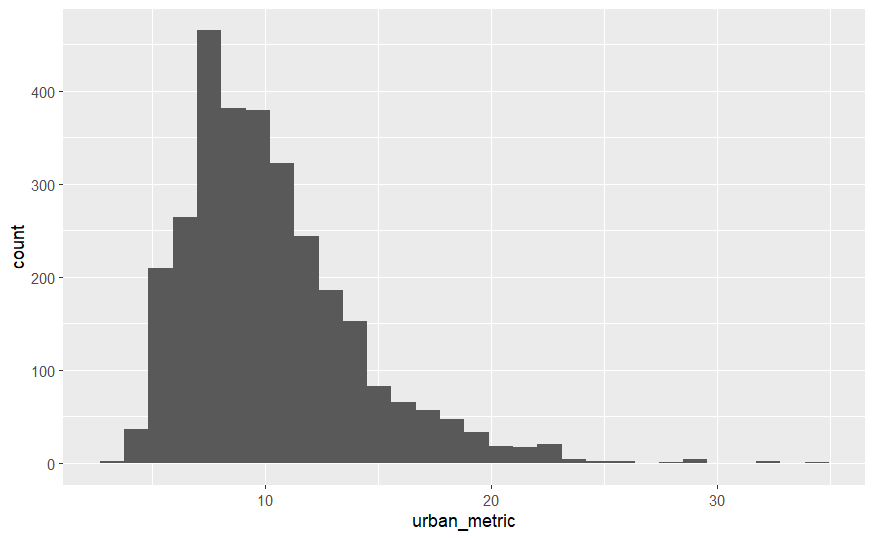

```r
ggplot(subset_cars,aes(urban_metric))+ geom_histogram()
```

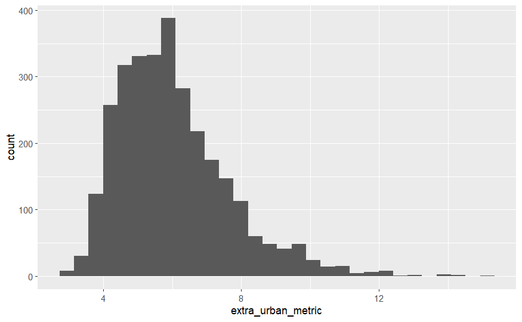

```r
ggplot(subset_cars,aes(extra_urban_metric))+ geom_histogram()
```

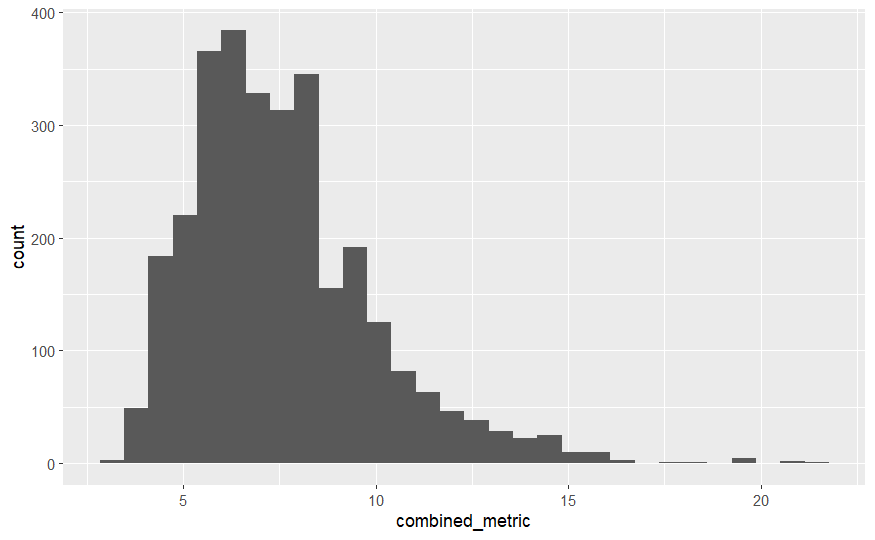

```r
ggplot(subset_cars,aes(combined_metric))+ geom_histogram()
```

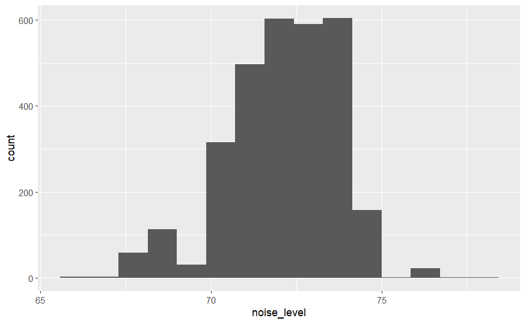

```r
selectNormalNoise = (60<subset_cars$noise_level) & (subset_cars$noise_level < 80)
ggplot(subset_cars[selectNormalNoise,],aes(noise_level))+ geom_histogram(bins = 15)
```

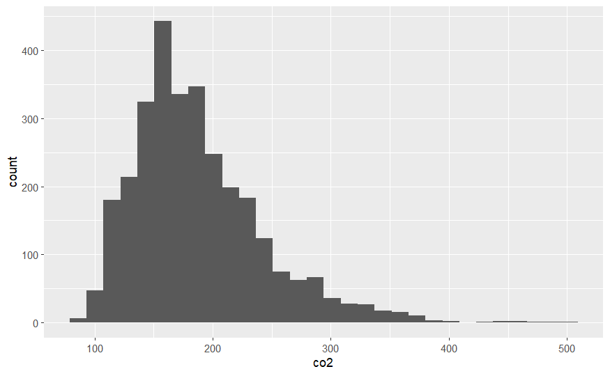

```r
ggplot(subset_cars,aes(co2))+ geom_histogram()
```

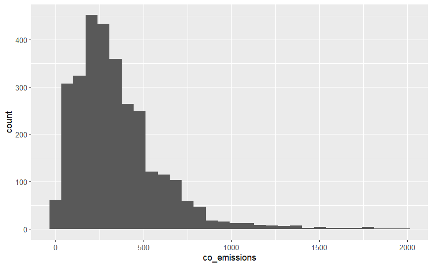

```r
ggplot(subset_cars,aes(co_emissions))+ geom_histogram()
```

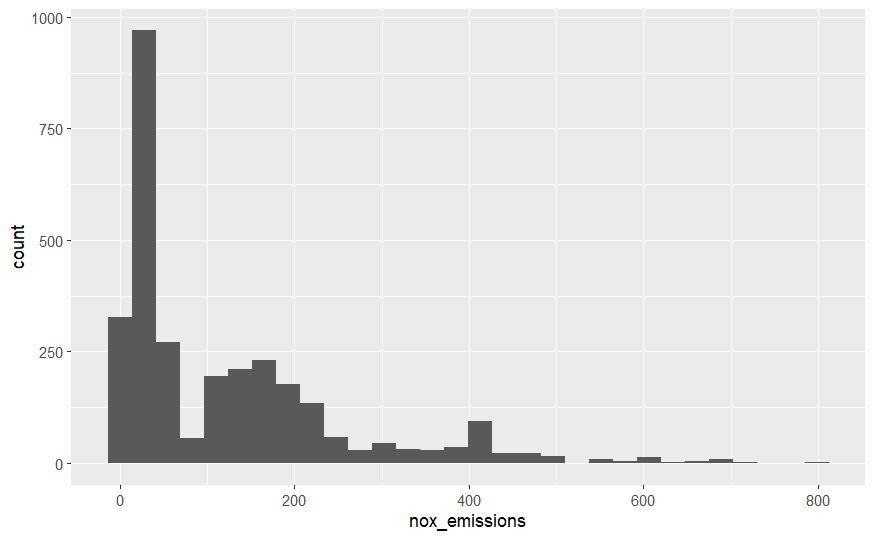

```r
selectNormalNox = (subset_cars$nox_emissions < 1000)
ggplot(subset_cars[selectNormalNox, ],aes(nox_emissions))+ geom_histogram()
```

Everything looks skewed to the right minus the noise emissions (maybe this is because it is on a log scale?). I’ll try transforming the noise. Then some outliers (points that ruined my plots so we filterd them out).

```r
selectBadRows <- !selectNormalNoise | !selectNormalNox
selectNormalRows <- !selectBadRows
#why doesn't this work? OK used cars_data instead of subset ...
subset.bad <- subset_cars[selectBadRows, ]
subset.trans <- subset_cars[selectNormalRows, ]
subset.trans$noise_level <- 1.26^(subset.trans$noise_level-70)
```

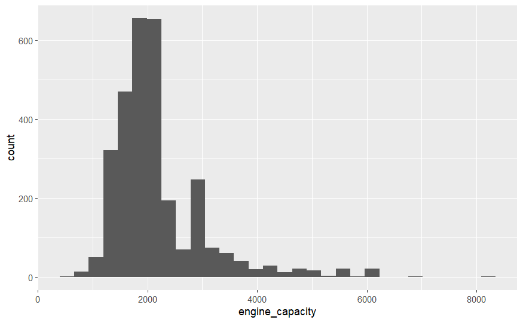

```r
ggplot(subset.trans,aes(engine_capacity))+ geom_histogram()
```

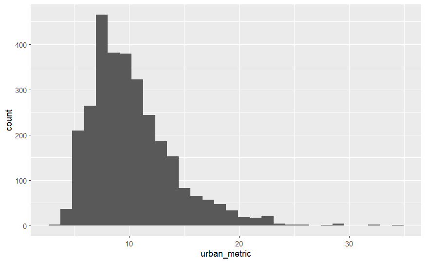

```r
ggplot(subset.trans,aes(urban_metric))+ geom_histogram()
```

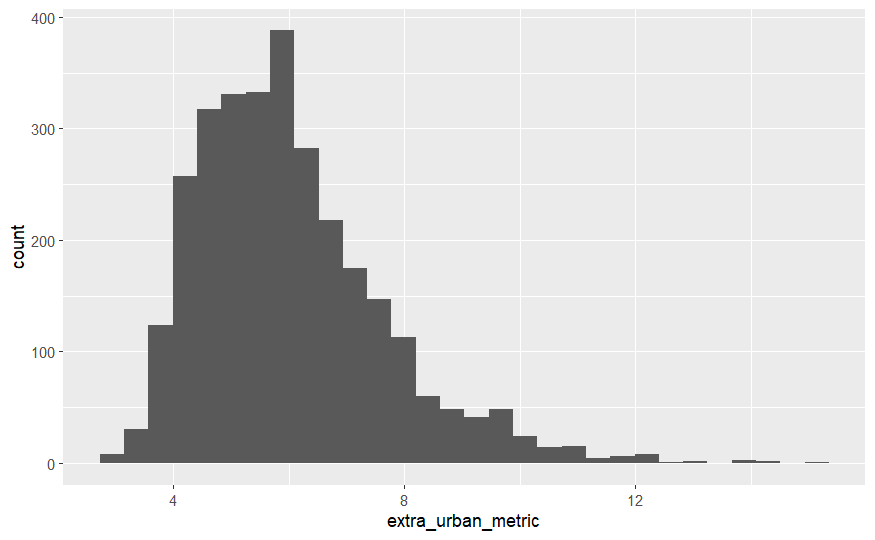

```r
ggplot(subset.trans,aes(extra_urban_metric))+ geom_histogram()
```

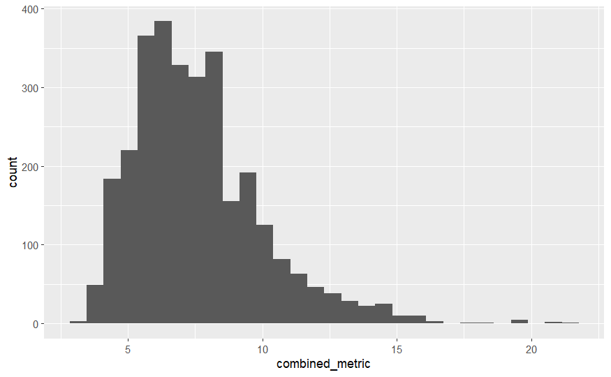

```r
ggplot(subset.trans,aes(combined_metric))+ geom_histogram()
```

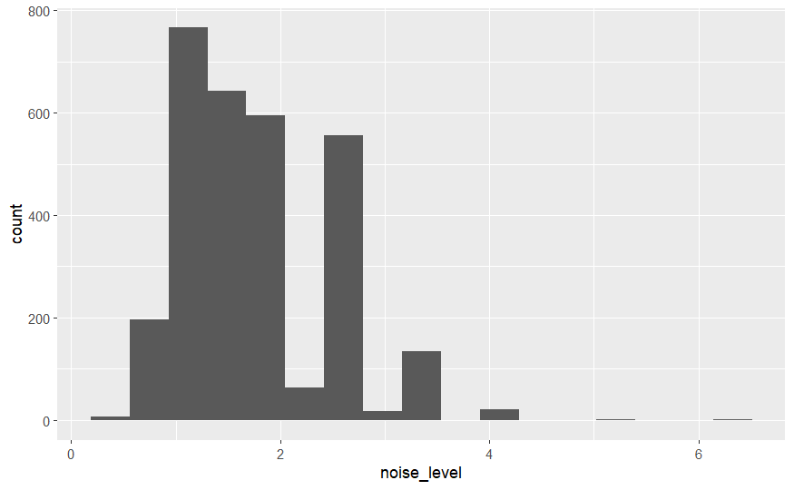

```r
ggplot(subset.trans,aes(noise_level))+ geom_histogram(bins = 17)
```

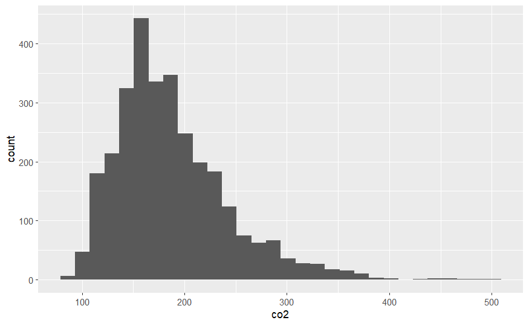

```r
ggplot(subset.trans,aes(co2))+ geom_histogram()
```

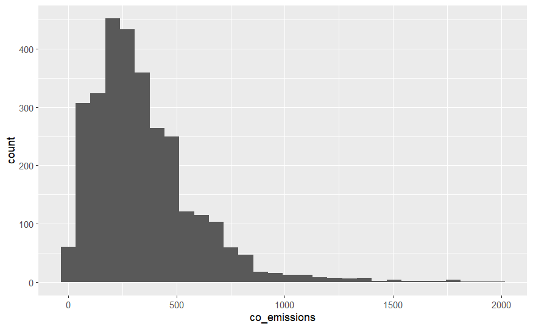

```r
ggplot(subset.trans,aes(co_emissions))+ geom_histogram()
```

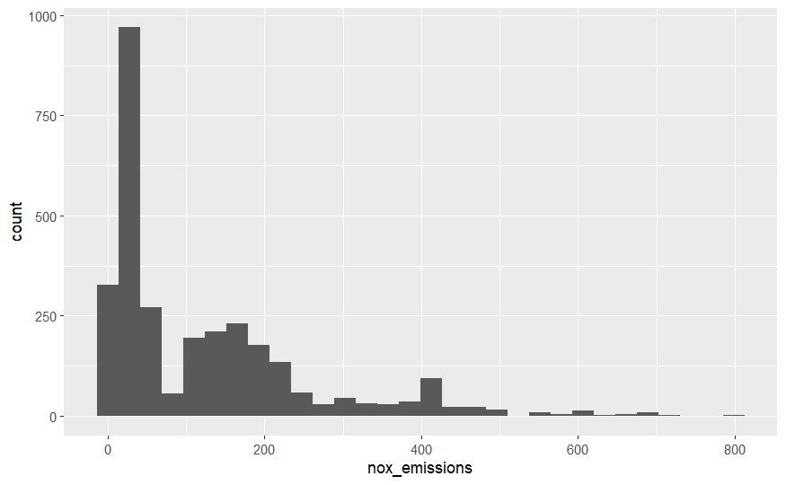

```r
ggplot(subset.trans,aes(nox_emissions))+ geom_histogram()
```

```r
subset.trans[order(subset.trans$noise_level,decreasing = TRUE), c("manufacturer","noise_level" )][1:20, ]
```

|  | manufacturer | noise_level |
| --- | --- | --- |
| 29213 | Chevrolet | 6.352788 |
| 14299 | Porsche | 5.041895 |
| 8863 | Mitsubishi | 4.001504 |
| 14112 | Mitsubishi | 4.001504 |
| 20108 | Volkswagen | 4.001504 |
| 21067 | Mitsubishi | 4.001504 |
| 36289 | Mercedes-Benz | 4.001504 |
| 12507 | BMW | 4.001504 |
| 26962 | Mitsubishi | 4.001504 |
| 17468 | Chrysler Jeep | 4.001504 |

[output cut: 10 more lines]

## plots for comparing variables

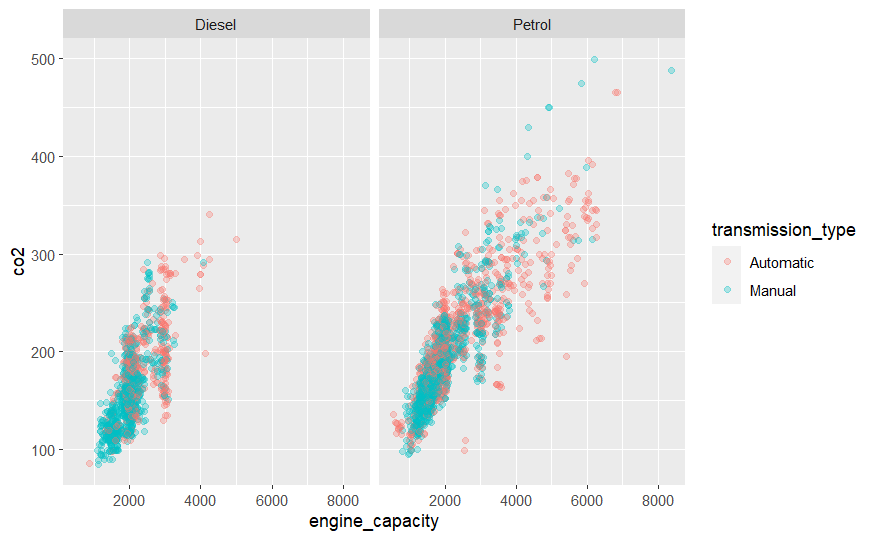

```r
ggplot(subset.trans, aes(x = engine_capacity, y = co2, color = transmission_type)) +
  geom_jitter(alpha = 0.3, width = 100) +
  facet_grid(~fuel_type)
```

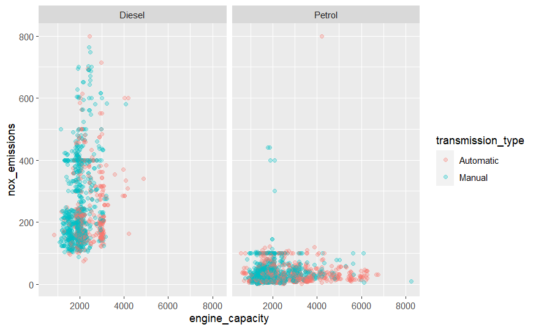

```r
ggplot(subset.trans, aes(x = engine_capacity, y = nox_emissions, color = transmission_type)) +
  geom_jitter(alpha = 0.3, width = 100) +
  facet_grid(~fuel_type)
```

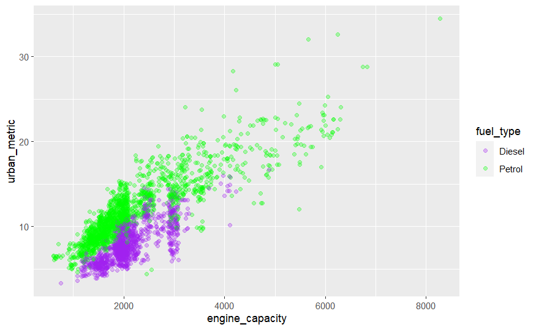

```r
ggplot(subset.trans, aes(x = engine_capacity, y = urban_metric, color = fuel_type)) +
  geom_jitter(alpha = 0.3, width = 100)+
  scale_color_manual(values=c("purple", "green"))
```

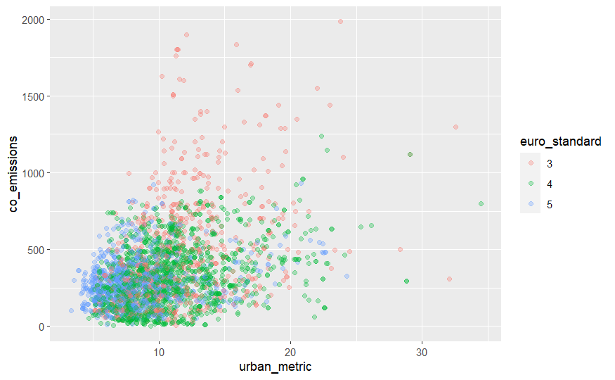

```r
ggplot(subset.trans, aes(x = urban_metric, y = co_emissions, color = euro_standard)) +
  geom_jitter(alpha = 0.3 )
```

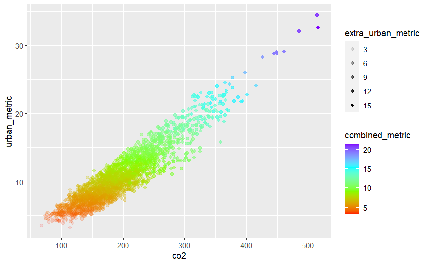

```r
ggplot(subset.trans, aes(x = co2, y = urban_metric, color = combined_metric, alpha = extra_urban_metric)) +
  geom_jitter( width=30)+
  scale_colour_gradientn(colours=rainbow(4))
```

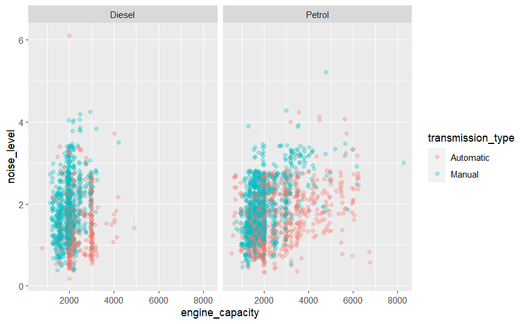

```r
# a non linear jitter would be more appropriate ...
ggplot(subset.trans, aes(x = engine_capacity, y = noise_level, color = transmission_type)) +
  geom_jitter(alpha = 0.3, width=50, height = 0.3 ) +
  facet_grid(~fuel_type)
```

These plot show that there are a lot of (near) linear relationships between variables and that the discrete variables are important. It makes it easy to find interesting rows. ## intersting rows

```r
subset.trans[subset.trans$engine_capacity> 8000,]
```

|  | manufacturer | model | description | euro_standard | transmission_type | engine_capacity | fuel_type | urban_metric | extra_urban_metric | combined_metric | noise_level | co2 | co_emissions | nox_emissions |
| --- | --- | --- | --- | --- | --- | --- | --- | --- | --- | --- | --- | --- | --- | --- |
| 36079 | Dodge | SRT10 | Cabriolet | 4 | Manual | 8285 | Petrol | 34.5 | 13.2 | 21.1 | 3.175797 | 488 | 796 | 9 |

```r
subset.trans[subset.trans$nox_emissions> 200 & subset.trans$fuel_type == "Petrol",]
```

|  | manufacturer | model | description | euro_standard | transmission_type | engine_capacity | fuel_type | urban_metric | extra_urban_metric | combined_metric | noise_level | co2 | co_emissions | nox_emissions |
| --- | --- | --- | --- | --- | --- | --- | --- | --- | --- | --- | --- | --- | --- | --- |
| 22186 | Proton | Wira | 1800 5 Door DOHC | 3 | Manual | 1834 | Petrol | 14.0 | 6.9 | 9.5 | 2.143990 | 227 | 710 | 440 |
| 27077 | Proton | Putra | 1800 DOHC | 3 | Manual | 1834 | Petrol | 14.0 | 6.9 | 9.5 | 1.823742 | 227 | 710 | 440 |
| 20835 | Renault | Laguna II Sport Tourer | 2.0 16V From VIN KG0K05 | 3 | Manual | 1998 | Petrol | 10.9 | 6.4 | 8.0 | 1.071794 | 190 | 600 | 300 |
| 28466 | Proton | Wira | 1800 4 Door DOHC | 3 | Manual | 1834 | Petrol | 14.0 | 6.9 | 9.5 | 2.351641 | 227 | 700 | 400 |
| 21588 | Honda | CR-V (up to 2001 YM) | 2.0i ES | 3 | Manual | 1973 | Petrol | 11.9 | 8.4 | 9.7 | 2.351641 | 229 | 1000 | 400 |
| 13484 | Chevrolet | Blazer | 4.3L V6 | 3 | Automatic | 4300 | Petrol | 19.1 | 11.1 | 14.0 | 2.520474 | 335 | 700 | 800 |

```r
subset.trans[subset.trans$co2> 440,]
```

|  | manufacturer | model | description | euro_standard | transmission_type | engine_capacity | fuel_type | urban_metric | extra_urban_metric | combined_metric | noise_level | co2 | co_emissions | nox_emissions |
| --- | --- | --- | --- | --- | --- | --- | --- | --- | --- | --- | --- | --- | --- | --- |
| 35407 | Lamborghini | Gallardo Model Year 2005 | 140 | 3 | Manual | 4961 | Petrol | 29.1 | 13.9 | 19.5 | 2.8292248 | 450 | 1119 | 79 |
| 36784 | Bentley Motors | Brooklands | CoupÃ© | 4 | Automatic | 6761 | Petrol | 28.8 | 14.1 | 19.5 | 0.7936508 | 465 | 294 | 31 |
| 16794 | Lamborghini | Gallardo Model Year 2004 | 140 | 4 | Manual | 4961 | Petrol | 29.1 | 13.9 | 19.5 | 2.5204738 | 450 | 1119 | 79 |
| 36079 | Dodge | SRT10 | Cabriolet | 4 | Manual | 8285 | Petrol | 34.5 | 13.2 | 21.1 | 3.1757969 | 488 | 796 | 9 |
| 30694 | Lamborghini | Murcielgo Model Year 2002/3 | 147 | 3 | Manual | 6192 | Petrol | 32.6 | 15.1 | 21.5 | 2.5204738 | 500 | 1300 | 100 |
| 17575 | Bentley Motors | Arnage (from 2007 model year) | T | 4 | Automatic | 6761 | Petrol | 28.8 | 14.1 | 19.5 | 0.6298816 | 465 | 294 | 31 |
| 12481 | Ferrari | All Models | 612 Scaglietti | 3 | Manual | 5748 | Petrol | 32.1 | 14.0 | 20.7 | 1.9546751 | 475 | 306 | 32 |

# PCA

## splitting into training and validation

```r
subset.transNoText <- subset.trans[ , -which(names(subset.trans) %in% c("manufacturer"
,"model","description" ))]
subset.transNoText <- na.omit(subset.transNoText)
```

```r
# it looks complicated because I had a bug and now I dont want to touch it ...
set.seed(180901)
train_ind <- sample.int(n=nrow(subset.trans),size=1500,replace=F)
subset.transNoText$inTrain = FALSE
subset.transNoText[train_ind,]$inTrain = TRUE
nrow(na.omit(subset.transNoText))
```

```
[1] 3000
```

```r
Xtrain = subset.transNoText[subset.transNoText$inTrain,]
Xtrain <- na.omit(Xtrain)
Xval = subset.transNoText[!(subset.transNoText$inTrain),]
Xval <- na.omit(Xval[!is.na(Xval),])
nrow(Xtrain)
```

```
[1] 1500
```

```r
nrow(Xval)
```

```
[1] 1500
```

## PCA on training

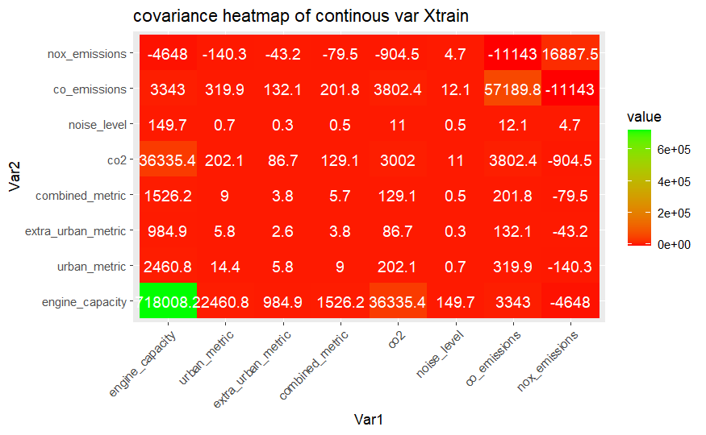

```r
continousCols <- c("engine_capacity", "urban_metric", "extra_urban_metric", "combined_metric","co2", "noise_level", "co_emissions", "nox_emissions")

ggplot(melt(round(cov(Xtrain[,continousCols]),1)),
       aes(x = Var1, y= Var2, fill= value))+
  geom_tile()+
  geom_text(aes(Var2, Var1, label = value),color = "white", size = 4)+
  theme(axis.text.x=element_text(angle=45, hjust=1,vjust=1)) +
  scale_fill_gradient(low = "red", high = "green")+
  ggtitle("covariance heatmap of continous var Xtrain")
```

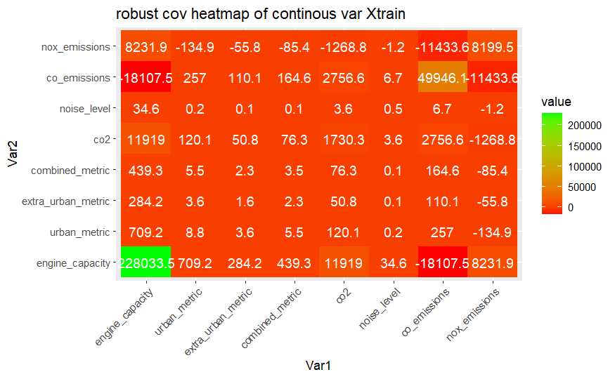

```r
ggplot(melt(round(covMcd(Xtrain[,continousCols], cor = TRUE)$cov,1)),
       aes(x = Var1, y= Var2, fill= value))+
  geom_tile()+
  geom_text(aes(Var2, Var1, label = value),color = "white", size = 4)+
  theme(axis.text.x=element_text(angle=45, hjust=1,vjust=1)) +
  scale_fill_gradient(low = "red", high = "green")+
  ggtitle("robust cov heatmap of continous var Xtrain")
```

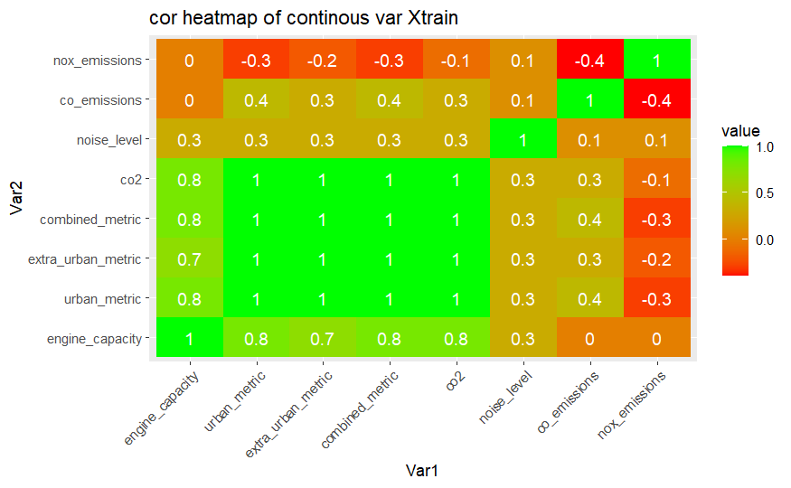

```r
ggplot(melt(round(cor(Xtrain[,continousCols]),1)),
       aes(x = Var1, y= Var2, fill= value))+
  geom_tile()+
  geom_text(aes(Var2, Var1, label = value),color = "white", size = 4)+
  theme(axis.text.x=element_text(angle=45, hjust=1,vjust=1)) +
  scale_fill_gradient(low = "red", high = "green")+
  ggtitle("cor heatmap of continous var Xtrain")
```

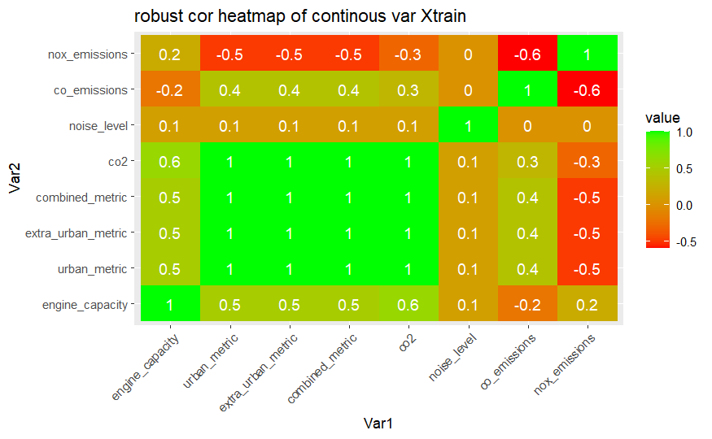

```r
ggplot(melt(round(covMcd(Xtrain[,continousCols], cor = TRUE)$cor,1)),
       aes(x = Var1, y= Var2, fill= value))+
  geom_tile()+
  geom_text(aes(Var2, Var1, label = value),color = "white", size = 4)+
  theme(axis.text.x=element_text(angle=45, hjust=1,vjust=1)) +
  scale_fill_gradient(low = "red", high = "green")+
  ggtitle("robust cor heatmap of continous var Xtrain")
```

```r
NA
NA
```

From the variance heatmap it is clearly seen that pca on the covariance matrix would be dominated by engine capacity therefore we have to scale the data (or use the correlation) before doing PCA.

```r
{
Xtrain.pca.unscaled = PcaClassic(Xtrain[,continousCols])
print(summary(Xtrain.pca.unscaled))
Xtrain.pca.unscaled$loadings
}
```

```
Call:
PcaClassic(x = Xtrain[, continousCols])
Importance of components:
                            PC1      PC2       PC3      PC4    PC5    PC6    PC7     PC8
Standard deviation     848.4774 245.4904 118.31342 30.53100 0.6454 0.6363 0.2878 0.03883
Proportion of Variance   0.9054   0.0758   0.01761  0.00117 0.0000 0.0000 0.0000 0.00000
Cumulative Proportion    0.9054   0.9812   0.99883  1.00000 1.0000 1.0000 1.0000 1.00000
                             PC1           PC2           PC3          PC4           PC5           PC6           PC7           PC8
engine_capacity     0.9986694073 -0.0101106064  0.0042065004 -0.050392404 -0.0002630839 -3.801125e-05  0.0001755488  2.208969e-06
urban_metric        0.0034317584  0.0055059331 -0.0030232307  0.061913749  0.9472610253 -1.024526e-01  0.0406785881 -2.943819e-01
extra_urban_metric  0.0013737526  0.0022218144 -0.0002319066  0.030664163 -0.1952011655  1.140301e-02  0.8371527590 -5.098966e-01
combined_metric     0.0021285844  0.0034416727 -0.0012861889  0.042173959  0.2221221081 -2.745481e-02  0.5429284997  8.082945e-01
co2                 0.0506547414  0.0617224764  0.0198587622  0.993287541 -0.0627940313  4.310173e-03 -0.0514607291 -2.224476e-04
noise_level         0.0002084503  0.0001608142  0.0005968358  0.002877939  0.1062563426  9.942837e-01  0.0098076698 -2.165651e-03
co_emissions        0.0054444488  0.9665795388  0.2478388202 -0.065344323 -0.0005725187 -5.349057e-05 -0.0002475313 -4.392907e-06
nox_emissions      -0.0067551092 -0.2485256205  0.9685828049 -0.003171447  0.0045745230 -1.040703e-03  0.0021599938  3.941431e-05
```

Most of the variance gets captured by the first PC and the loadings aren’t interesting because of the poor scaling.

```r
Xtrain.pca.scaled = PcaClassic(Xtrain[,continousCols],scale =TRUE,crit.pca.distances=0.99)
summary(Xtrain.pca.scaled)
```

```
Call:
PcaClassic(x = Xtrain[, continousCols], scale = TRUE, crit.pca.distances = 0.99)
Importance of components:
                         PC1    PC2    PC3     PC4     PC5    PC6     PC7     PC8
Standard deviation     2.200 1.1491 0.9390 0.80133 0.52045 0.1980 0.07619 0.01632
Proportion of Variance 0.605 0.1651 0.1102 0.08027 0.03386 0.0049 0.00073 0.00003
Cumulative Proportion  0.605 0.7700 0.8802 0.96048 0.99434 0.9992 0.99997 1.00000
```

```r
Xtrain.pca.scaled$loadings
```

```
                          PC1         PC2         PC3         PC4         PC5          PC6          PC7           PC8
engine_capacity     0.3645715  0.29326537 -0.19390237 -0.18300493  0.83298929 -0.122086007 -0.034878340  0.0012082266
urban_metric        0.4479022 -0.02425818 -0.07575889 -0.01116939 -0.11590667  0.697165918 -0.267225145 -0.4712186421
extra_urban_metric  0.4421129  0.01302090 -0.06484149  0.08742907 -0.30825381 -0.693183870 -0.314964762 -0.3432073961
combined_metric     0.4506531 -0.01006524 -0.07098758  0.02985197 -0.20020543  0.111520878 -0.279754493  0.8124643782
co2                 0.4457684  0.09606274 -0.07957677  0.10147217 -0.18866030  0.003166202  0.860101300 -0.0075139800
noise_level         0.1596613  0.28138372  0.90745525 -0.26750009 -0.01695428 -0.002592673 -0.002373134 -0.0005973052
co_emissions        0.1715616 -0.60932945  0.34212847  0.60002775  0.34856752 -0.020644828  0.016532182 -0.0004438165
nox_emissions      -0.1195182  0.67338613  0.02365217  0.71830583 -0.01457356  0.075305707 -0.099275648  0.0021989360
```

In would save 3 PC, the first 2 for sure because they capture a lot variances and the third because it is basically the noise level (look loadings) which is a variable that sticks out.